# identifying_viral_metrics_environmental

Bridget Hegarty, James Riddell

7/23/2022

This Rmarkdown file takes outputs from viral identification tools and merges them into one file, “{dataset}_merged_viral_id_outputs.csv”, which is the input for identifying_viral_metrics_environmental.Rmd.

Please reach out to James Riddell (riddell.26@buckeyemail.osu.edu) or Bridget Hegarty (email) regarding any issues, or open an issue on github.

```r
library(ggplot2)
library(plyr)
library(reshape2)
library(viridis)
library(tidyr)
library(dplyr)
library(readr)
library(data.table)
library(here)
```

1. For this script’s inputs, the user must merge each viral identification tool output with the following specified filenames into one tab-separated file. Replace the filenames with their paths if needed into the variables in the ‘inputs’ chunk.

   General filenames for each tool: Checkv: quality_summary.tsv VIBRANT: VIBRANT_genome_quality_${assembly}.tsv Virsorter: VIRSorter_global-phage-signal.csv Virsorter2: final-viral-score.tsv DeepVirFinder: ${assembly}.fasta_gt2500bp_dvfpred.txt Kaiju: ${assembly}.kaiju.names.out
2. Make sure all fasta headers (assembly, contig) are consistent within and across tools. Chunks for each tool do contain some lines for cleaning up these features, but due to their variability it will be the user’s responsibility to make sure they match across tools.
3. Check each chunk and ensure all columns are accounted for. For example, if you don’t have “assembly” and called it something else, please either remove it from this script or modify your input files.
4. This script is designed for contigs > 3000 basepairs. It can be modified to be higher or lower, but going lower will greatly increase the size of the dataframe and memory usage.

```r
# dataset name for file organization and outputs for metrics file
dataset_name <- "lake_michigan"
# checkV
checkV_path <- "merged_outputs/merged_checkv_assemblies.tsv"
# VIBRANT
vibrant_path <- "merged_outputs/merged_vibrant_assemblies.tsv"
# DeepVirFinder
dvf_path <- "merged_outputs/merged_dvf_assemblies.tsv"
# Virsorter
vs_path <- "merged_outputs/merged_virsorter_assemblies.tsv"
# Virsorter2
vs2_path <- "merged_outputs/merged_vs2_assemblies.tsv"
# Kaiju
kj_path <- "merged_outputs/merged_kaiju_assemblies.tsv"
# KB cutoff
KB_CUTOFF <- 3000
```

# All Viral Contigs

## checkV

```r
checkV <- fread(checkV_path,
                sep="\t",
                header = T,
                select = c(
                    'contig_id',
                    'provirus',
                    'completeness',
                    'contamination',
                    'viral_genes',
                    'host_genes',
                    'gene_count',
                    'contig_length',
                    'checkv_quality'
                    )
                ) %>%
    rename(
        contig = contig_id,
        checkv_provirus = provirus,
        checkv_completeness = completeness,
        checkv_contamination = contamination,
        checkv_viral_genes = viral_genes,
        checkv_host_genes = host_genes,
        checkv_total_genes = gene_count,
        checkv_length = contig_length
        )
```

```
|--------------------------------------------------|
|==================================================|
```

```r
checkV$method = 'checkv'
checkV$contig <- gsub('_', '', checkV$contig)
```

## VIBRANT

```r
vb_c <- fread(vibrant_path,
              header = T,
              sep = "\t",
              select = c(
                  'scaffold',
                  'type',
                  'Quality'
                  )
              ) %>%
    rename(
        contig = scaffold,
        vibrant_quality = Quality
        )
vb_c$method <- "vibrant"
vb_c$vibrant_prophage <- "No"
vb_c$vibrant_prophage[grep("_fragment_", vb_c$contig)] <- "Yes"
vb_c$contig <- gsub("_fragment_.*", "", vb_c$contig)
vb_c$contig <- gsub('_', '', vb_c$contig)
```

## DeepVirFinder

```r
dvf_c <- fread(dvf_path,
               header = T,
               sep = "\t",
               select = c(
                   'name',
                   'assembly',
                   'score',
                   'pvalue'
                   )
               ) %>%
    rename(
        contig = name
        )
dvf_c$contig <- gsub('_', '', dvf_c$contig)
dvf_c$bh_pvalue <- p.adjust(dvf_c$pvalue, method = "BH")
```

## VirSorter

```r
vs_c <- fread(vs_path,
              select = c(
                  '## Contig_id',
                  'Nb genes contigs',
                  'Nb genes',
                  'Category',
                  'Nb phage hallmark genes'
                  )
              ) %>% drop_na(`## Contig_id`)
vs_c$`## Contig_id` <- sub("VIRSorter_", "", vs_c$`## Contig_id`)
vs_c$`## Contig_id` <- sub("-circular", "", vs_c$`## Contig_id`)
vs_c$`## Contig_id` <- gsub("_", "", vs_c$`## Contig_id`)
vs_c <- separate(vs_c, col = `## Contig_id`, into = c("assembly", "contig"), sep="--")

# convert to numeric
vs_c$category <- as.numeric(vs_c$Category)
vs_c <- vs_c %>% drop_na(category)
```

## VirSorter2

```r
vs2_c <- fread(vs2_path,
                    header = T,
                    sep = '\t',
                    select = c(
                        'seqname',
                        'dsDNAphage',
                        'RNA',
                        'ssDNA',
                        'max_score',
                        'max_score_group',
                        'hallmark',
                        'viral',
                        'cellular'
                    )
               ) %>%
              separate(
                  col = seqname,
                  into = c("contig", "type"),
                  sep = "\\|\\|",
                  remove = T
                  )
vs2_c$contig <- gsub("_", "", vs2_c$contig)
```

## Kaiju

(parsing when reading the file in “fails” for sequences that weren’t classified)

```r
kj_c <- fread(kj_path)
```

```
|--------------------------------------------------|
|==================================================|
```

```r
colnames(kj_c) <-c(
    "Classified",
    "Contig",
    "NCBI_taxon",
    "len",
    "ID_best",
    "IDs_all",
    "Seq",
    "Name",
    "assembly"
    )
kj_c$Contig <- gsub('_', '', kj_c$Contig)
kj_c <- setDT(kj_c)[, c("assembly", "contig") := tstrsplit(Contig, "--")]
kj_c <- setDT(kj_c)[, c("Kaiju_Viral", "Kingdom") := tstrsplit(Name, ";", keep = c(1, 2))]
```

```r
# Quick glimpse of cellular vs viral sequence classification by Kaiju by assembly
table(kj_c$assembly, kj_c$Kaiju_Viral)
```

```
          cellular organisms Viruses
  group1               62224  247010
  group10              67179  199474
  group11              63667  236054
  group12              60291  228900
  group13              48399  210367
  group2               68366  255916
  group3               64565  267195
  group4               59066  251641
  group5               62446  231030
  group6               67448  214978
  group7               56393  250774
  group8               55126  245704
  group9               60544  255409
```

## Merging

```r
viruses <- full_join(x=vs2_c, y=dvf_c, by = "contig")
viruses <- full_join(x=viruses, y=checkV, by = "contig")
viruses <- full_join(x=viruses, y=vb_c, by = "contig")
viruses <- full_join(x=viruses, y=vs_c, by = "contig")
viruses <- full_join(x=viruses, y=kj_c, by = "contig")
```

Remove contigs not greater than the basepair length cutoff (3000)

```r
viruses <- viruses %>% filter(checkv_length > KB_CUTOFF)
```

Use the next code chunk to check if any contigs are missing from checkv. If yes, then there is a mix up in contig names since checkv should contain all contig names even if they are identified as non-viral.

```r
v_missing <- viruses[is.na(viruses$checkv_uniq_contig),]
```

calculate percent viral/host/unknown

```r
viruses$percent_host <- viruses$checkv_host_genes/viruses$checkv_total_genes*100
viruses$percent_viral <- viruses$checkv_viral_genes/viruses$checkv_total_genes*100
viruses$percent_unknown <- 100-(viruses$checkv_host_genes+viruses$checkv_viral_genes)/viruses$checkv_total_genes*100
```

get rid of NAs for downstream processing

```r
# checkV
viruses$percent_viral[is.na(viruses$percent_viral)] <- 0
viruses$percent_unknown[is.na(viruses$percent_unknown)] <- 0

# VIBRANT
viruses$vibrant_quality[is.na(viruses$vibrant_quality)] <- 0

# DeepVirFinder
viruses$score[is.na(viruses$score)] <- 0
viruses$bh_pvalue[is.na(viruses$bh_pvalue)] <- 0

# VirSorter2
viruses$viral[is.na(viruses$viral)] <- 0
viruses$hallmark[is.na(viruses$hallmark)] <- 0

#Virsorter
viruses$category[is.na(viruses$category)] <- 0

# Kaiju
viruses$Kaiju_Viral[is.na(viruses$Kaiju_Viral)] <- "unknown"
viruses$Kingdom[is.na(viruses$Kingdom)] <- "unknown"
```

```r
viruses_filename <- 'merged_viral_id_outputs.csv'
write.csv(viruses, paste(dataset_name, viruses_filename, sep='_'))
```

TODO: ADD ENVIRONMENTAL METRICS LIKE SHANNON, ALPHA DIVERSITY.

VIBRANT Quality == “High Quality Draft”: +1 Quality == “Medium Quality Draft”: +1 Quality == “Low Quality Draft” & provirus == TRUE: +0.5

Kaiju: Kaiju_viral = “cellular organisms”: -1 Kaiju_viral = “Viruses”: +1

CheckV viral_genes == 0 and host_genes >= 1: keep_score = 0 If 3*viral_genes <= host_genes: keep_score = 0 If length > 50,000 and hallmark == 0: keep_score = 0 If %unknown >= 75: +0.5

Users can decide which combination is appropriate for them and only need to run the chunks for the appropriate tools.

```r
getting_viral_set_1 <- function(input_seqs,
                                include_vibrant=FALSE,
                                include_virsorter2=FALSE,
                                include_deepvirfinder=FALSE,
                                include_tuning=FALSE,
                                include_kaiju=FALSE,
                                include_virsorter=FALSE) {

  keep_score <- rep(0, nrow(input_seqs))

  if (include_vibrant) {
    keep_score[input_seqs$vibrant_quality=="high quality draft"] <- keep_score[input_seqs$vibrant_quality=="high quality draft"] + 1
    keep_score[input_seqs$vibrant_quality=="medium quality draft"] <- keep_score[input_seqs$vibrant_quality=="medium quality draft"] + 1
    keep_score[input_seqs$vibrant_quality=="low quality draft" & input_seqs$provirus=="Yes"] <- keep_score[input_seqs$vibrant_quality=="low quality draft" & input_seqs$provirus=="Yes"] + 0.5
#    keep_score[input_seqs$vibrant_quality=="low quality draft"] <- keep_score[input_seqs$vibrant_quality=="low quality draft"] + 0.5
  }

  if (include_virsorter2) {
    keep_score[input_seqs$viral>=50] <- keep_score[input_seqs$viral>=50] + 0.5
    keep_score[input_seqs$viral>=95] <- keep_score[input_seqs$viral>=95] + 0.5
  }

  if (include_virsorter) {
    keep_score[input_seqs$category==1] <- keep_score[input_seqs$category==1] + 1
    keep_score[input_seqs$category==2] <- keep_score[input_seqs$category==2] + 1
    keep_score[input_seqs$category==3] <- keep_score[input_seqs$category==3] + 0.5
    keep_score[input_seqs$category==4] <- keep_score[input_seqs$category==4] + 1
    keep_score[input_seqs$category==5] <- keep_score[input_seqs$category==5] + 1
    keep_score[input_seqs$category==6] <- keep_score[input_seqs$category==6] + 0.5
  }

  if (include_deepvirfinder) {
    keep_score[input_seqs$score>=0.7 & input_seqs$checkv_length<20000] <- keep_score[input_seqs$score>=0.7 & input_seqs$checkv_length<20000] + 0.5
   keep_score[input_seqs$score>=0.9 & input_seqs$checkv_length<20000] <- keep_score[input_seqs$score>=0.9 & input_seqs$checkv_length<20000] + 0.5
  }

  if (include_kaiju) {
    keep_score[input_seqs$Kaiju_Viral=="cellular organisms"] <- keep_score[input_seqs$Kaiju_Viral=="cellular organisms"] - 1
    keep_score[input_seqs$Kaiju_Viral=="Viruses"] <- keep_score[input_seqs$Kaiju_Viral=="Viruses"] + 1
  }

  if (include_tuning) {
    keep_score[input_seqs$hallmark>2] <- keep_score[input_seqs$hallmark>2] + 1
    keep_score[input_seqs$percent_unknown>=75] <- keep_score[input_seqs$percent_unknown>=75] + 0.5
    keep_score[input_seqs$percent_viral>=50] <- keep_score[input_seqs$percent_viral>=50] + 0.5
    #keep_score[input_seqs$hallmark>=(input_seqs$checkv_viral_genes/5)] <- keep_score[input_seqs$hallmark>=(input_seqs$checkv_viral_genes/5)] + 1 #add some ratio
    keep_score[input_seqs$viral_genes==0 & input_seqs$host_genes>=1] <- 0
    keep_score[((input_seqs$viral_genes*3) <= input_seqs$host_genes) & input_seqs$checkv_provirus=="No"] <- 0 # consider accounting for provirus designation
#    keep_score[(input_seqs$viral_genes*3) <= input_seqs$host_genes] <- 0 # consider accounting for provirus designation
    keep_score[input_seqs$contig_length>50000 & input_seqs$hallmark==0] <- 0
  }

  return(keep_score)

}
```

```r
viruses$keep_score_high_precision <- getting_viral_set_1(viruses, include_deepvirfinder = F,
                                              include_vibrant = T,
                                              include_virsorter2 = F,
                                              include_kaiju = T,
                                              include_tuning = T,
                                              include_virsorter = F)
```

```r
table(viruses$keep_score_high_precision>=1)
```

```
 FALSE   TRUE
128619 126243
```

```r
viruses$keep_score_vb <- getting_viral_set_1(viruses, include_deepvirfinder = F,
                                              include_vibrant = T,
                                              include_virsorter2 = F,
                                              include_kaiju = F,
                                              include_tuning = F,
                                              include_virsorter = F)
viruses$keep_score_dvf <- getting_viral_set_1(viruses, include_deepvirfinder = T,
                                              include_vibrant = F,
                                              include_virsorter2 = F,
                                              include_kaiju = F,
                                              include_tuning = F,
                                              include_virsorter = F)
viruses$keep_score_vs2 <- getting_viral_set_1(viruses, include_deepvirfinder = F,
                                              include_vibrant = F,
                                              include_virsorter2 = T,
                                              include_kaiju = F,
                                              include_tuning = F,
                                              include_virsorter = F)
viruses$keep_score_vs <- getting_viral_set_1(viruses, include_deepvirfinder = F,
                                              include_vibrant = F,
                                              include_virsorter2 = F,
                                              include_kaiju = F,
                                              include_tuning = F,
                                              include_virsorter = T)
viruses$keep_score_tuning <- getting_viral_set_1(viruses, include_deepvirfinder = F,
                                              include_vibrant = F,
                                              include_virsorter2 = F,
                                              include_kaiju = F,
                                              include_tuning = T,
                                              include_virsorter = F)
viruses$keep_score_kj <- getting_viral_set_1(viruses, include_deepvirfinder = F,
                                              include_vibrant = F,
                                              include_virsorter2 = F,
                                              include_kaiju = T,
                                              include_tuning = F,
                                              include_virsorter = F)
viruses$keep_score_all <- getting_viral_set_1(viruses, include_deepvirfinder = T,
                                              include_vibrant = T,
                                              include_virsorter2 = T,
                                              include_kaiju = T,
                                              include_tuning = T,
                                              include_virsorter = T)
```

# Plot of how many methods identify a contig

```r
viruses_high <- viruses[viruses$keep_score_all>=1,]
viruses_high_mod <- viruses %>% select(keep_score_vb, keep_score_dvf,keep_score_vs2, keep_score_vs, keep_score_kj)
viruses_high_mod <- apply(viruses_high_mod, c(1,2), function(x) {if (x >= 1) {x <- 1} else {x <- 0}})
viruses_high_mod <- as_tibble(viruses_high_mod)
virusHighCount <- function(df, tool_combo) {
    tb <- rowSums(df[df[,tool_combo]>0,])
    if (length(tb) == 0) {
        return (0)
    }
    else {
        return (table(tb))
    }
}
sm <- as.data.frame(rbind(table(rowSums(viruses_high_mod[viruses_high_mod$keep_score_vb>0,])),
                          table(rowSums(viruses_high_mod[viruses_high_mod$keep_score_dvf>0,])),
                          table(rowSums(viruses_high_mod[viruses_high_mod$keep_score_vs2>0,])),
                          table(rowSums(viruses_high_mod[viruses_high_mod$keep_score_vs>0,])),
                          table(rowSums(viruses_high_mod[viruses_high_mod$keep_score_kj>0,]))
                          )
)
sm <- as.data.frame(
    rbind(
        virusHighCount(viruses_high_mod, "keep_score_vb"),
        virusHighCount(viruses_high_mod, "keep_score_dvf"),
        virusHighCount(viruses_high_mod, "keep_score_vs2"),
        virusHighCount(viruses_high_mod, "keep_score_vs"),
        virusHighCount(viruses_high_mod, "keep_score_kj")
    )
)
sm$method <- c("vibrant", "deepvirfinder", "virsorter2", "virsorter", "kaiju")
sm
```

| 1 | 2 | 3 | 4 | 5 | method |
| --- | --- | --- | --- | --- | --- |
| 495 | 927 | 856 | 219 | 53 | vibrant |
| 67513 | 59095 | 24865 | 8617 | 53 | deepvirfinder |
| 4447 | 16402 | 20311 | 8489 | 53 | virsorter2 |
| 1907 | 8928 | 14707 | 8655 | 53 | virsorter |
| 26760 | 60986 | 27302 | 8652 | 53 | kaiju |

Create list of contigs considered viral

```r
c_list <- data.frame(viruses_high$checkv_uniq_contig)
write_tsv(c_list, paste(dataset_name, "viruses_high_uniq_contig_list.tsv", sep='_'))
```

Export keep_score_high and list of contigs considered viral by the combined tool.

```r
write_tsv(viruses_high, paste(dataset_name, "viruses_high.tsv", sep='_'))
```

```r
sm_m <- reshape2::melt(sm)
colnames(sm_m) <- c("primary_method", "number_methods", "number")
```

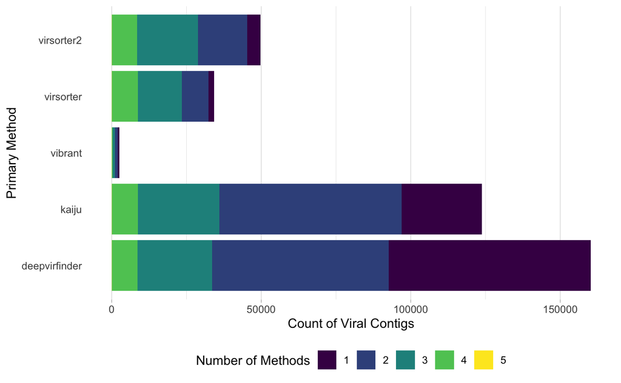

```r
ggplot(sm_m, aes(x=primary_method, y=number,
                   fill=number_methods)) +
  geom_bar(stat="identity") +
  theme_light() +
  coord_flip() +
  theme(
    panel.grid.major.y = element_blank(),
    panel.border = element_blank(),
    axis.ticks.y = element_blank(),
    legend.position = "bottom"
  ) +
  scale_fill_manual(name = 'Number of Methods',
                     values = alpha(c(viridis(5)), 1)) +
  xlab("Primary Method") +
  ylab("Count of Viral Contigs")
```